# Online University: Predicting Success and Failure Rates in the UK

**Motivation and Outline of this Project**

Online learning has exploded in the past decade as a viable alternative to traditional education methods. The benefits from online education are quite clear for pupils. Online classes cater to a student’s schedule rather than that of the university, and most online programs are significantly more affordable than their on-campus alternatives.

Online programs also benefit the universities that offer them. Presenting a course or entire degree online allows universities to collect new data about students that simply never existed before. Universities can use this data to better understand how students interact with class material and more accuractly measure which students are struggling vs. succeeding. If a university can predict which students may fail or fall behind, the university can better support those at risk. These predictions help universities offer assistance more efficienctly and optimize how they allocate tutoring or support servies.

This project **contains the code I wrote to analyze student performance at the Online University (OU) in the UK**. Therefore, this page provides explanations of each code section and futher detail where necessary. These sections are meant to make the data exploration and modeling easier to follow. For more information about the presentation that uses this analysis, please get in touch or send me a message!

**Motivation and Outline of this Project**

To follow this analyis or explore on your own, you need to download the OU dataset. OU provides the dataset for free on its website here: https://analyse.kmi.open.ac.uk/open_dataset

OU exposes 7 CSV files that function similarly to tables in a relational database schema. Their dataset contains student performance in 7 modules offered over 2 years as well as demographic information about each of the ~30k students who enrolled in the modules. Lastly, the dataset captures interactions between students and the Virtual Learning Environment (VLE) - OU’s platform to share class resources, homework assignments, and exams with students.

Let’s load the data to see what we’re working with:

```r
# look csv files from the directory and extract all the filenames
csv.files <- list.files(pattern = "*.csv")
(file.names <- sapply(strsplit(csv.files, ".csv"), "[", 1))
```

```
##  [1] "assessments"          "courses"              "student.clicks.test"
##  [4] "student.clicks.train" "studentAssessment"    "studentInfo"
##  [7] "studentRegistration"  "studentsClicks"       "studentVle"
## [10] "vle"
```

```r
# read all the files into memory, giving them their name as the variable for list access
file.list <- lapply(as.list(setNames(csv.files, file.names)), read.csv)
```

In this study, we attempt to predict whether a student passes or fails a class. The studentInfo file contains the students' marks in each module:

```r
# encoding for the student's final marks
table(file.list$studentInfo$final_result)
```

```
##
## Distinction        Fail        Pass   Withdrawn
##        3024        7052       12361       10156
```

```r
file.list$studentInfo$final_result_encoding <- -1
file.list$studentInfo[which(file.list$studentInfo$final_result %in% c("Pass","Distinction")),"final_result_encoding"] <- 1
file.list$studentInfo[which(file.list$studentInfo$final_result == "Fail"),"final_result_encoding"] <- 0
table(file.list$studentInfo$final_result_encoding)
```

```
##
##    -1     0     1
## 10156  7052 15385
```

Before performing analysis, we encode students' results in each class as 1, 0, or -1. 1 represents students who receive “Distinction” or “Pass” as final results. 0 is reserved for students who fail, and -1 labels students that withdrew. This encoding prepares the data well for binary classification techniques. In this study, we analyze P/F rates only. Withdrawals deserve an entirely separate analysis which is out of scope for this project.

This code below contains general helper functions used throughout the analysis as well as methods to merge the csv files together. The CSV methods often contain hard-coded column references specific to this analysis ONLY. Regardless, they should give a sense of how the CSV’s relate to each other.

```r
# sort by and generate percents for any nested grouping
gb.func <- function(df, cnt.col, ..., sort.by.col = T, g.func = n_distinct){
  cnt.col <- sym(cnt.col)
  cnt.col.name <- paste0("count_", quo_name(cnt.col))
  cnt.col.perc <- paste0("percent_", quo_name(cnt.col))
  cnt.sym <- sym(cnt.col.name)
  df.group <- df %>%
    dplyr::group_by_(...) %>%
    dplyr::summarise(!!cnt.col.name := g.func(!!cnt.col)) %>%
    dplyr::mutate(!!cnt.col.perc := !!cnt.sym /sum(!!cnt.sym))
  if (sort.by.col == T){
    return(as.data.frame(df.group %>% dplyr::arrange(desc(!!cnt.sym))))
  }
  else{
    return(as.data.frame(df.group))
  }
}

# rows to columns based on the key
r2c.func <- function(df, k, varr) {
    key.q <- enquo(k)
    varr.q <- enquo(varr)
    s <- quos(!!varr.q)
    df %>% gather(variable, varr, !!!s) %>%
        unite(temp, !!key.q, variable) %>%
        spread(temp, varr)
}

# custom plots used throughout the analysis
custom.plots <- list(
  gg.bar = function(d, y.f, x.f, t = NULL){
    ggplot(data = d,
           mapping = aes(x = as.factor(d[,x.f]), y = d[,y.f])) +
    geom_bar(stat = "identity") +
    labs(x = x.f, y = "count", title = ifelse(!is.null(t),t,""))
  },
  gg.comp.line = function(d, y.f, x.f, f, t = NULL) {
    ggplot(data = d,
           mapping = aes(x = d[,x.f], y = d[,y.f], colour = as.factor(d[,f]))) +
     geom_line(aes(group = as.factor(d[,f]))) +
      geom_point() +
      theme(legend.position="none") +
    labs(x = x.f, y = "percent %", title = ifelse(!is.null(t),t,""))
  }
)

# convert logits to probs
logit.to.prob <- function(logit){ exp(logit) / (1 + exp(logit))}

# number the course assessments by their order. function to keep it from always updating if rerunning
map.stud.course <- function(csr = course.assessments.raw, si = student.info){

  # order correctly then create assigment numbers
  css <- csr[with(csr, order(code_module, code_presentation, date)),]
  ca <- as.data.frame(plyr::ddply(css, .(code_module, code_presentation),
                                  mutate, assessment_number = seq_along(date)))

  # generate exam date and the seq along dates and the dates between assignments
  ca$date <- with(ca, ifelse(is.na(date) & assessment_type=="Exam",module_presentation_length,date))
  ca$dates_bw_assessment <- with(ca, ave(date, c(code_module, code_presentation), FUN=function(x) c(0, diff(x))))
  ca$dates_bw_assessment <- with(ca, ifelse(assessment_number==1,date,dates_bw_assessment))

  # join the student info. MUST do this first to get all the assignments, b/c not studentAssessment file incomplete
  keep.cols <- c(colnames(ca), "id_student", "date_registration", "final_result", "final_result_encoding")
  sic <- merge(si, ca, by = c("code_module","code_presentation"))[,keep.cols]
  return(list(ca=ca,sic=sic))
}

# mapping the student performance
map.stud.perf <- function(sic, sa = file.list$studentAssessment){
  sp <- merge(sic, sa, by = c("id_student", "id_assessment"), all.x = TRUE)
  # get the average student performance
  sp <- as.data.frame(plyr::ddply(sp, .(code_module, code_presentation, id_assessment),
                      mutate, assessment_avg = mean(score, na.rm = TRUE)))

  # create columns for submission, lateness, etc.
  sp$assessment_submitted <- ifelse(is.na(sp$date_submitted), 0, 1)
  sp$assessment_late <- with(sp,ifelse(!is.na(date_submitted) & date_submitted <= date, 0, 1))
  # SCORE = 0 if no submission
  sp$score <- with(sp, ifelse(is.na(score), 0, score))
  sp$points_from_avg <- sp$score - sp$assessment_avg
  return(sp)
}

student.click.prep <- function(clicks, assgn = c(1,2,3,4)){
  # get the rows of the assignments, because cumulative clicks counted too
  sta <- as.data.frame(
    with(clicks, clicks[assessment_number %in% assgn & !is.na(assessment_type),])
  )
  # manipulation
  cols.to.remove <- c("count_sum_click","assessment_type","date_unregistration")
  sta <- sta[,!colnames(sta) %in% cols.to.remove]

  # create specific columns for each assignments and its attributes
  stud.assgn.spread <- r2c.func(
    sta,assessment_number,
    c(score, weight, date, date_submitted, assessment_submitted, assessment_late,
      assessment_avg,points_from_avg, clicks_bw_assessments, dates_bw_assessment)
  )
  return(stud.assgn.spread)
}

# final prep
final.student.prep <- function(sd, ss){
  # create the final dataframe for analysis
  fd <- merge(sd, ss,
  by = c("id_student", "code_module", "code_presentation","final_result_encoding"),
  all.x = TRUE)
  # remove extra columns from the join
  fd <- fd[, -grep(".y$", colnames(fd))]
  # SHOULDN'T BE HARD CODED _ MAY CAUSE AN ERROR IF COLS CHANGE
  fd[,16:length(fd)] <- apply(fd[,16:length(fd)],2,as.numeric)
  return(fd)
}

#Merge the VLE files together to get the activity type of each student click
map.stud.clicks <- function(sp, sv = file.list$studentVle, v = file.list$vle, csv.w = F){
  # vle information
  svi <- merge(sv, v, by=c("id_site","code_module","code_presentation"))
  spc <- gb.func(svi, "sum_click", "id_student", "code_module", "code_presentation", "date", g.func = sum)

  # get the assignment dates merged with clicks
  sf <- merge(spc, sp, by=c("id_student", "code_module", "code_presentation","date"), all = TRUE)
  sf$count_sum_click <- with(sf, ifelse(is.na(count_sum_click), 0, count_sum_click))
  # get clicks between assessments
  sf <- sf %>%
    dplyr::group_by(id_student, code_module, code_presentation) %>%
    fill(assessment_number, .direction = "up")

  sf <- as.data.frame(
    plyr::ddply(sf, .(id_student, code_module, code_presentation, assessment_number),
              mutate, clicks_bw_assessments = cumsum(count_sum_click))
  )
  # order correctly
  sf <- sf[with(sf,order(id_student, code_module, code_presentation, date)),]
  if (csv.w == T){
    write.csv(sf, file="studentFinalClicks.csv")
  }
  return(sf)
}
```

The code below contains helper functions for Latent Class Analysis. We utilize the poLCA package in R later on to discover if students fall into latent classes who have different pass / fail rates.

```r
# compute the results for train
lca.analysis <- function(data, f, k, s, probs.start = NULL) {
  set.seed(s)
  class.names <- sapply(1:k, function(k) {paste0("Class_", k)})
  if(is.null(probs.start)){
    lca.f <- poLCA(f, data, nclass = k, nrep = 25, tol = .001, verbose = FALSE, graphs = FALSE)
  }
  else{
    lca.f <- poLCA(f, data, nclass = k, nrep = 25, tol = .001, probs.start = probs.start, verbose = FALSE, graphs = FALSE)
  }
  # this says the odds-ratio of being in class 2 is LOWER/HIGHER is you pass.
  # If negative logit / odds < 1, more likely to be in class 1 than class K.
  logits <- coef(lca.f)[2,]
  odds.ratio <- exp(logits)
  # to make this more interpretable in terms of odds, we can reverse as below:
  odds.pct <- (odds.ratio-1)*100
  odds.pass.class <- 1/odds.ratio
  odds.fail.class <- (odds.pass.class-1)*100
  # probability of class 1 reference class
  probs <- logit.to.prob(coef(lca.f)[2,])
  # FINAL RESULTS
  lca.logistic.res <- cbind(logits,odds.ratio,odds.pct,
                            odds.pass.class,odds.fail.class,probs)
  colnames(lca.logistic.res) <- c("logits", "Odds Ratio Chg in Class if Pass",
                                  "Odds Pct Chg in Class if Pass","Odds Ratio Chg in Class if Fail",
                                  "Odds Pct Chg in Class if Fail", "Probability")

  rownames(lca.logistic.res) <- class.names[-1]
  odds.table <- t(lca.logistic.res)

  # look at cross-classification table
  posteriors <- data.frame(lca.f$posterior, predclass=lca.f$predclass)
  class.table <-  plyr::ddply(posteriors, .(predclass), function(x) colSums(x[,1:k]))
  class.table.perc <- apply(class.table, 2, function(x) x / sum(x))[,-1]
  rownames(class.table.perc) <- class.names
  class.table.error <- 1 - sum(diag(class.table.perc)) / sum(class.table.perc)
  # entropy estimates
  nume.entr <- -sum(lca.f$posterior * log(lca.f$posterior))
  ##Denominator (n*log(K)): ## n is a sample size, and K is a number of class
  deno.entr <- nrow(lca.f$posterior)*log(k)
  ##Relative Entropy
  entropy <- 1-(nume.entr/deno.entr)
  return(list(
    results=lca.f,
    odds.table=odds.table,
    class.table.perc=class.table.perc,
    class.table.error=class.table.error,
    entropy=entropy
  ))
}

# plots and results for the LCA analysis
collect.lca.results <- function(df){
  lca.res.df <- data.frame(
    k = num.clusters,
    lca.bic = sapply(df, function(b) {b$results$bic}),
    lca.aic = sapply(df, function(a) {a$results$aic}),
    entropy = sapply(df, function(e) {e$entropy})
  )
  with(lca.res.df,{
    plot(k, lca.aic, type = "l", col = "red", xlab = "Number of Clusters",
         ylab = "Estimate", xlim = c(min(k),max(k)), xaxt = "n",
         ylim = c(min(lca.aic),max(lca.bic)),
         main = "AIC and BIC vs Number of Clusters")
    lines(k, lca.bic, col = "blue", xlim = c(min(k),max(k)))
    axis(1, at = k, labels = k)
  })

  with(lca.res.df,{
    plot(k, entropy, type = "b", col = "black", xlab = "Number of Clusters",
         ylab = "Estimate", xlim = c(min(k),max(k)), xaxt = "n",
         ylim = c(min(entropy)-.05,max(entropy)+.05),
         main = "Entropy vs Number of Clusters")
    axis(1, at = k, labels = k)
  })
  return(lca.res.df)
}
```

The code below contains helper functions for Logistic Regression. We use logistic regression as one of the classification techniques to predict whether a student will pass or fail a class:

```r
# wrapper for percentages
table.perc <- function(d) {
  tbl <- round(rbind(table(d),table(d)/length(d)),3)
  rownames(tbl) <- c("Actual","Percent")
  return(tbl)
}

# accuracy of confusion matrix helper
accuracy <- function(glm.obj){
  return(sum(diag(glm.obj$conf.matrix.val) / sum(glm.obj$conf.matrix.val)))
}

# helper function to look at false positive and negative rates in logistic reg
compute.lgres <- function(df,m,k,pr.vals){
  pr.val.comp <- sapply(pr.vals, function(i) {
    reg.model <- logistic.res(m, df, i)
    false.pos <- reg.model$conf.matrix.perc[1,2]
    false.neg <- reg.model$conf.matrix.perc[2,1]
    acc <- accuracy(reg.model)
    res <- rbind(false.pos, false.neg, acc)
    return(res)
  })
  colnames(pr.val.comp) <- pr.vals
  rownames(pr.val.comp) <- c(paste0(k,"_false_pos"),
                             paste0(k,"_false_neg"),
                             paste0(k,"_acc"))
  pr.val.comp <- t(pr.val.comp)
  return(pr.val.comp)
}

# helper function for logistic regression
logistic.res <- function(glm.obj, ds, pr) {
  model.coeff <- 0
  model.aic <- 0
  fv <- 0
  if (typeof(glm.obj) == "list"){
    model.coeff <- round(cbind(summary(glm.obj)$coef),4)
    model.aic <- AIC(glm.obj)
    fv <- ifelse(glm.obj$fitted.values>=pr,1,0)
  }
  else{
    fv <- ifelse(glm.obj>=pr,1,0)
  }
  tbl.orig <- table.perc(ds$final_result_encoding)
  tbl <- table.perc(fv)
  matrix.val <- table(ds$final_result_encoding, fv)
  matrix.perc <- round(prop.table(table(ds$final_result_encoding, fv),1),2)
  res <- list(model.coeff = model.coeff,
              model.aic = model.aic,
              tbl.orig = tbl.orig,
              tbl.model = tbl,
              conf.matrix.val = matrix.val,
              conf.matrix.perc = matrix.perc)
  return(res)
}
```

**Exploring the Data**

After loading the CSVs into dataframes, we learn more about the data itself. We start with the “Student Info”. This dataframe contains demographic information about the students together with their results for the courses / modules they take.

*Student Info*

In the code below, we make a copy of the “Student Info” CSV. We display the number of distinct values in each column. Note that the number of distinct students is less than the number of rows in the dataframe. The relationship between students and modules is many-to-many. Therefore, duplicate student IDs appear in this dataframe if a student takes more than one module. The rest of the demographic information, however, should be 1-to-1 (i.e. one gender, age group, region, etc. per student).

```r
# making a local copy fine, as dataset not that big. NO withdrawals only
student.info.nw <- as.data.frame(file.list$studentInfo[file.list$studentInfo$final_result_encoding != -1,])
# get the registration date into the student info file
student.info <- merge(student.info.nw, file.list$studentRegistration, by = c("id_student","code_module", "code_presentation"))

# remove outliers from this study, all from similar region
logged.imd.factors <- sort(unique(student.info$imd_band))[-1]
student.info <- student.info[student.info$imd_band %in% logged.imd.factors,]
student.info$imd_band <- as.factor(as.numeric(student.info$imd_band))
levels(student.info$imd_band) <- logged.imd.factors


# NOTE - THERE ARE 9 STUDENTS WHO FAILED BUT STILL UNREGISTERED
failed.un.register <- student.info[!is.na(student.info$date_unregistration),]

# create late registration column
student.info$is_late_registration <- ifelse(student.info$date_registration>0,1,0)

#get the number of unqiue values in each column
unique.instances <- as.data.frame(apply(student.info, 2, function(cl) {length(unique(cl))}))
colnames(unique.instances) <- c("unique instances")
unique.instances
```

```
##                       unique instances
## id_student                       20316
## code_module                          7
## code_presentation                    4
## gender                               2
## region                              13
## highest_education                    5
## imd_band                            10
## age_band                             3
## num_of_prev_attempts                 7
## studied_credits                     46
## disability                           2
## final_result                         3
## final_result_encoding                2
## date_registration                  303
## date_unregistration                  5
## is_late_registration                 3
```

```r
# get the length of the dataframe to show the number of student & course pairings
nrow(student.info)
```

```
## [1] 21562
```

```r
# number of students by gender
gb.gender <- gb.func(student.info, "id_student", "gender")

# number of students by imd band
(gb.imd.band <- gb.func(student.info, "id_student", "imd_band", sort.by.col = F))
```

```
##    imd_band count_id_student percent_id_student
## 1     0-10%             1969         0.09691868
## 2     10-20             2152         0.10592636
## 3    20-30%             2193         0.10794448
## 4    30-40%             2307         0.11355582
## 5    40-50%             2102         0.10346525
## 6    50-60%             2106         0.10366214
## 7    60-70%             1919         0.09445757
## 8    70-80%             1953         0.09613113
## 9    80-90%             1858         0.09145501
## 10  90-100%             1757         0.08648356
```

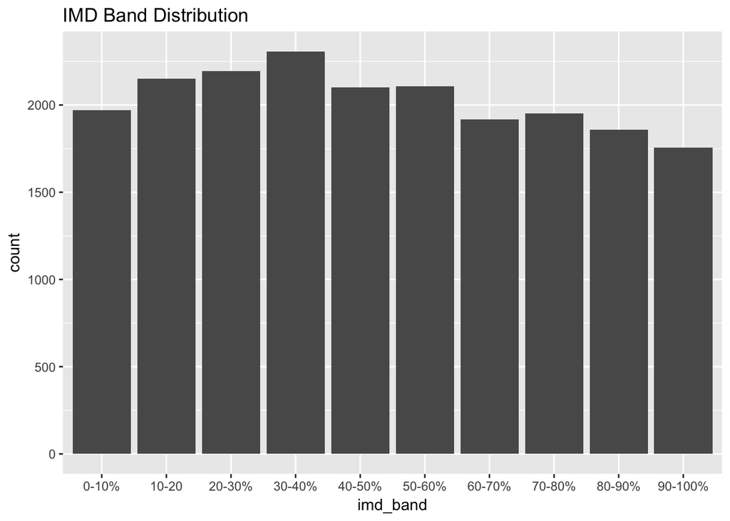

```r
custom.plots$gg.bar(gb.imd.band, "count_id_student", "imd_band", "IMD Band Distribution")
```

```r
# number of students by age band
gb.age <- gb.func(student.info, "id_student", "age_band", sort.by.col = F)

# number of students by highest education
(gb.ed <- gb.func(student.info, "id_student", "highest_education"))
```

```
##             highest_education count_id_student percent_id_student
## 1       A Level or Equivalent             9155        0.450630045
## 2          Lower Than A Level             7899        0.388806852
## 3            HE Qualification             2963        0.145845639
## 4             No Formal quals              175        0.008613900
## 5 Post Graduate Qualification              124        0.006103564
```

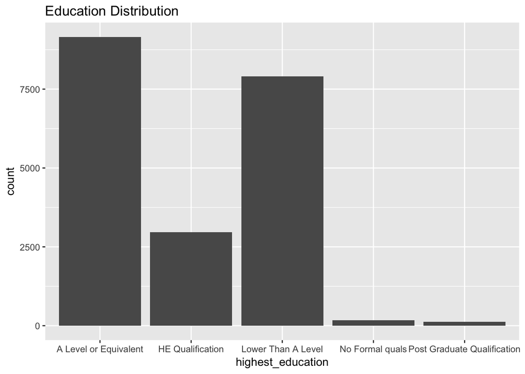

```r
custom.plots$gg.bar(gb.ed,"count_id_student", "highest_education", "Education Distribution")
```

The bar charts reveal that some explanatory variables are evenly distributed while others are not. For example, the “IMD Band” - an indicator of socio-economic status in the UK - contains about roughly 10% students in each bucket. Unsurprisingly, prior education is non-uniform. Far more enrollees have a high school diploma or less than students with a college degree or more.

The code below continues the data exploration phase, looking at Pass / Fail rates among different groups.

```r
# number of students by code module
(gb.student.module <- gb.func(student.info, "id_student", "code_module", sort.by.col = F))
```

```
##   code_module count_id_student percent_id_student
## 1         AAA              599          0.0278877
## 2         BBB             5450          0.2537362
## 3         CCC             2278          0.1060571
## 4         DDD             3778          0.1758927
## 5         EEE             2105          0.0980027
## 6         FFF             5035          0.2344150
## 7         GGG             2234          0.1040086
```

```r
# final grade by education
(pf.by.ed <- gb.func(student.info, "id_student", "highest_education", "final_result_encoding", sort.by.col = F))
```

```
##              highest_education final_result_encoding count_id_student
## 1        A Level or Equivalent                     0             2563
## 2        A Level or Equivalent                     1             6722
## 3             HE Qualification                     0              709
## 4             HE Qualification                     1             2289
## 5           Lower Than A Level                     0             3283
## 6           Lower Than A Level                     1             4715
## 7              No Formal quals                     0               91
## 8              No Formal quals                     1               84
## 9  Post Graduate Qualification                     0               27
## 10 Post Graduate Qualification                     1               98
##    percent_id_student
## 1           0.2760366
## 2           0.7239634
## 3           0.2364910
## 4           0.7635090
## 5           0.4104776
## 6           0.5895224
## 7           0.5200000
## 8           0.4800000
## 9           0.2160000
## 10          0.7840000
```

```r
# number of students by code module and final result
(pf.by.code <- gb.func(student.info, "id_student", "code_module", "final_result_encoding", sort.by.col = F))
```

```
##    code_module final_result_encoding count_id_student percent_id_student
## 1          AAA                     0               89          0.1480865
## 2          AAA                     1              512          0.8519135
## 3          BBB                     0             1748          0.3200879
## 4          BBB                     1             3713          0.6799121
## 5          CCC                     0              748          0.3283582
## 6          CCC                     1             1530          0.6716418
## 7          DDD                     0             1359          0.3590489
## 8          DDD                     1             2426          0.6409511
## 9          EEE                     0              541          0.2567632
## 10         EEE                     1             1566          0.7432368
## 11         FFF                     0             1648          0.3265306
## 12         FFF                     1             3399          0.6734694
## 13         GGG                     0              725          0.3245300
## 14         GGG                     1             1509          0.6754700
```

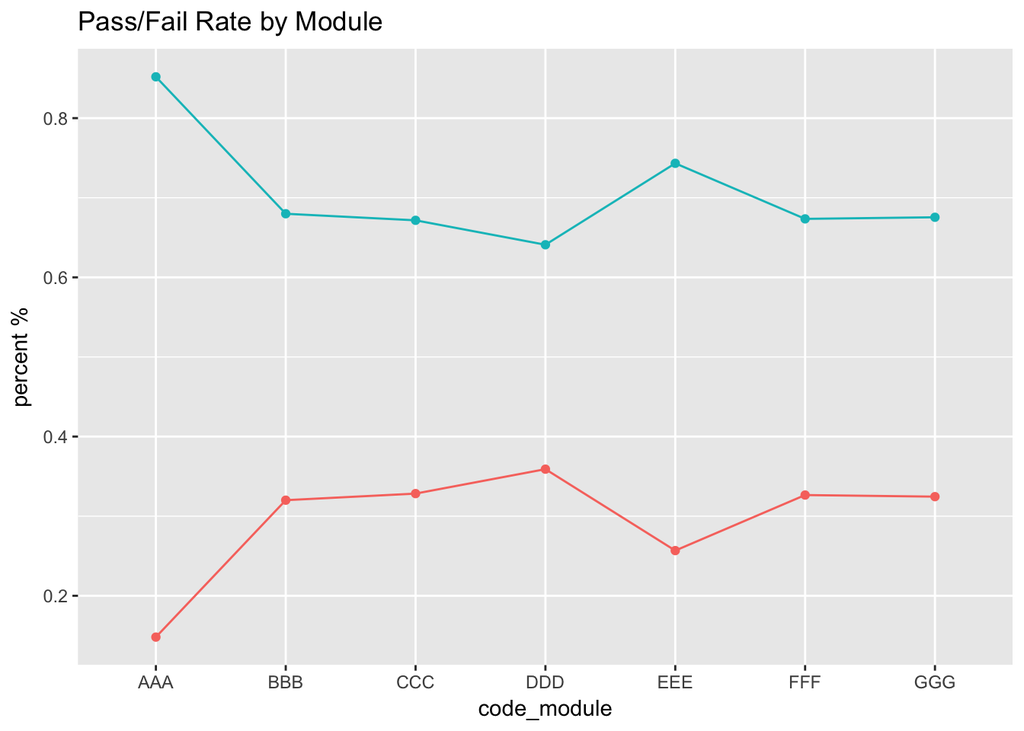

```r
custom.plots$gg.comp.line(pf.by.code, "percent_id_student", "code_module", "final_result_encoding","Pass/Fail Rate by Module")
```

```r
(pf.by.imd <- gb.func(student.info, "id_student", "imd_band", "final_result_encoding", sort.by.col = F))
```

```
##    imd_band final_result_encoding count_id_student percent_id_student
## 1     0-10%                     0              883          0.4423848
## 2     0-10%                     1             1113          0.5576152
## 3     10-20                     0              881          0.4041284
## 4     10-20                     1             1299          0.5958716
## 5    20-30%                     0              808          0.3634728
## 6    20-30%                     1             1415          0.6365272
## 7    30-40%                     0              763          0.3266267
## 8    30-40%                     1             1573          0.6733733
## 9    40-50%                     0              677          0.3178404
## 10   40-50%                     1             1453          0.6821596
## 11   50-60%                     0              678          0.3181605
## 12   50-60%                     1             1453          0.6818395
## 13   60-70%                     0              524          0.2695473
## 14   60-70%                     1             1420          0.7304527
## 15   70-80%                     0              573          0.2902736
## 16   70-80%                     1             1401          0.7097264
## 17   80-90%                     0              475          0.2521231
## 18   80-90%                     1             1409          0.7478769
## 19  90-100%                     0              411          0.2305104
## 20  90-100%                     1             1372          0.7694896
```

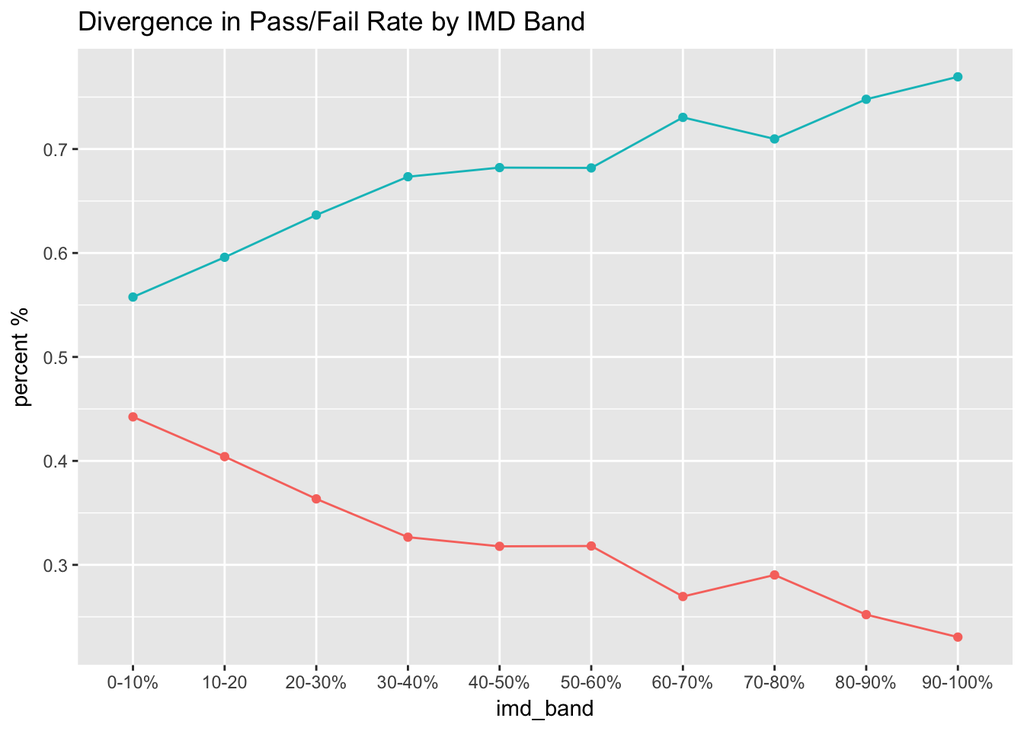

```r
custom.plots$gg.comp.line(pf.by.imd, "percent_id_student", "imd_band", "final_result_encoding","Divergence in Pass/Fail Rate by IMD Band")
```

```r
# SOME IMPORTANT DIFFERENCES BY MODULE / PRES
pf.by.code.pres <- gb.func(student.info, "id_student", "code_module", "code_presentation", "final_result_encoding", sort.by.col = F)
```

In the plots above, the blue line indicates the percentage of students who pass a class, while the red line plots the percentage who fail. Course modules have a roughly consistent Pass-to-Fail ratio, with a couple courses easier than others. IMD Band, on the other hand, does not have a consistent Pass-to-Fail ratio within each group. Students with higher socioeconomic status tend to pass more often than they fail. Substantial research has been done to analyze the effect of wealth and class on school performance, so that will not be the main focus of this analysis, although it is a significant factor that we account for in our predictions.

*Modules and Assessments*

The code below looks at the available courses and their assessments.

```r
# merge them together on their shared columns - code_module and code_presentation
course.assessments.raw <- merge(file.list$courses,file.list$assessments,by=c("code_module","code_presentation"))

course.mod.count <- gb.func(course.assessments.raw, "id_assessment",
                            "code_module", "code_presentation", sort.by.col = F)

course.mod.type.count <- gb.func(course.assessments.raw, "id_assessment",
                                 "code_module", "code_presentation", "assessment_type", sort.by.col = F)

(assessment.types <- gb.func(course.assessments.raw, "id_assessment", "assessment_type", sort.by.col = T))
```

```
##   assessment_type count_id_assessment percent_id_assessment
## 1             TMA                 106             0.5145631
## 2             CMA                  76             0.3689320
## 3            Exam                  24             0.1165049
```

We merge the courses and their assessments together. The resulting dataframe contains the course’s module number, presentation, and length. For each course, the dataframe includes the assessments and their type, due date, and course weight.

*Student Performance*

We retrieve the student information data.

```r
students.in.courses <- map.stud.course()
students.performance <- map.stud.perf(students.in.courses$sic)

students.clicks <- file.list$studentsClicks
students.clicks <- students.clicks[,!colnames(students.clicks) %in%
                                     c("X", "percent_sum_click", "id_assessment",
                                       "module_presentation_length", "is_banked")]

head(students.clicks[,c("id_student","code_module","code_presentation","date",
                   "count_sum_click","assessment_number","clicks_bw_assessments")])
```

```
##   id_student code_module code_presentation date count_sum_click
## 1       6516         AAA             2014J  -23              28
## 2       6516         AAA             2014J  -22              82
## 3       6516         AAA             2014J  -20              41
## 4       6516         AAA             2014J  -17               7
## 5       6516         AAA             2014J  -12               2
## 6       6516         AAA             2014J   -6              16
##   assessment_number clicks_bw_assessments
## 1                 1                    28
## 2                 1                   110
## 3                 1                   151
## 4                 1                   158
## 5                 1                   160
## 6                 1                   176
```

The table above is a sneak peak of the students.clicks dataframe. It shows some of the important columns. The “assessment_number” is a given assignment’s position in the module. The date is a given day, where 0 is the courses start date. “count_sum_click” is the total number of clicks on the VLE from a given student on a given day. “clicks_bw_assessments” are the cumulative clicks from a given student in between each assessment. Negative dates correspond to clicks from a student prior to the courses start date. They are counted as before the first assessment.

**Latent Class Analysis**

We strive to predict whether a student will pass or fail a class, yet we know that the Pass/Fail rate is significantly different depending on demographics. Therefore, we start with Latent Class Analysis to see if we can come up with interpretable subgroups within the overall population.

We run LCA for clusters 2-5, selecting the best cluster based on analysis of BIC, AIC, and entropy for each $k$.

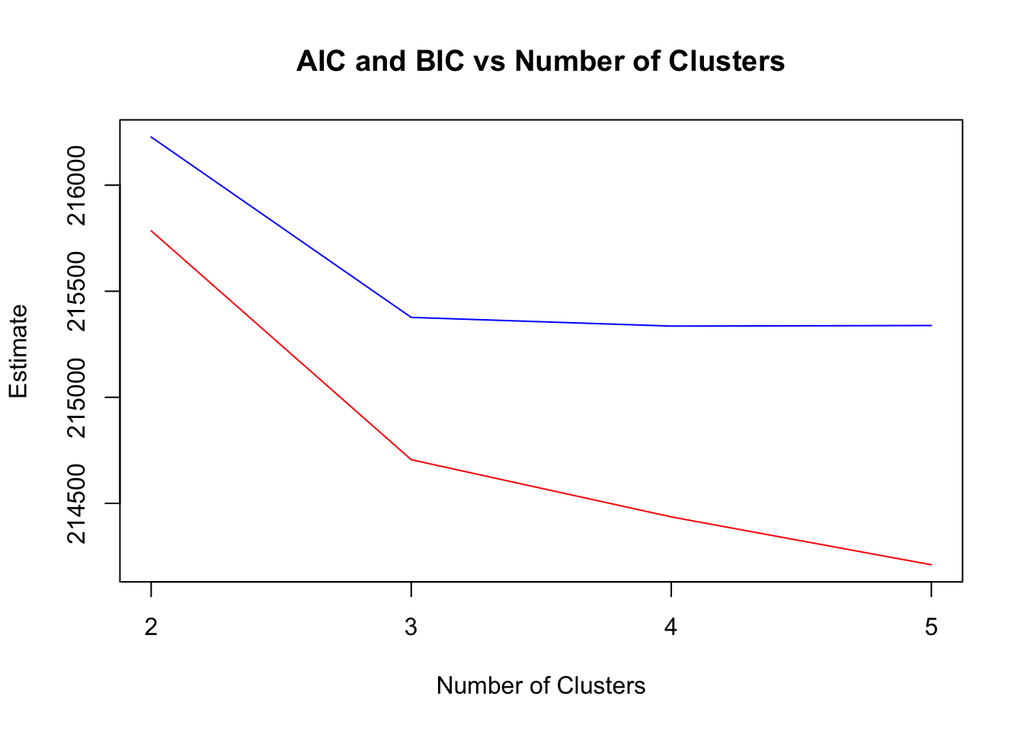

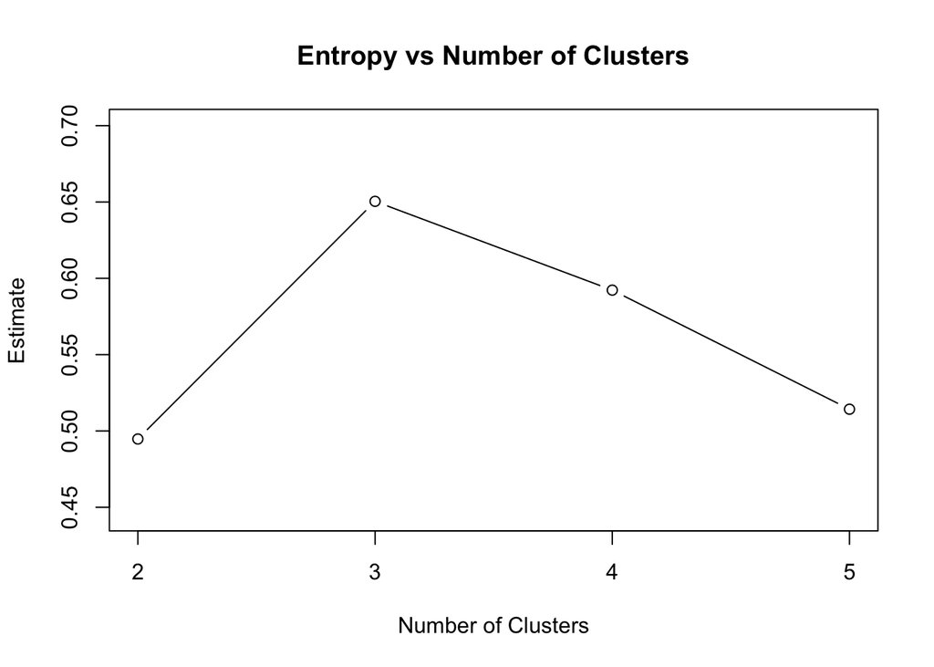

```
##   k  lca.bic  lca.aic   entropy
## 1 2 216227.1 215785.0 0.4947535
## 2 3 215376.7 214705.9 0.6504305
## 3 4 215335.7 214436.3 0.5922617
## 4 5 215338.6 214210.6 0.5142564
```

```r
#lca train and test data
set.seed(1019)
sample.arr <- 1:nrow(student.info)
indices <- sample(sample.arr,.7*length(sample.arr))
student.train <- student.info[indices,]
student.test <- student.info[-indices,]

# function for train and test
lca.f.train.trim <- with(student.train, cbind(imd_band,highest_education,gender,age_band,region) ~ final_result_encoding)
lca.f.test.trim <- with(student.test, cbind(imd_band,highest_education,gender,age_band,region) ~ final_result_encoding)

# creating the training data for lca and applying the functions
num.clusters <- 2:5
lca.res.train <- lapply(num.clusters, function(k) lca.analysis(student.train, lca.f.train.trim, k, 17))

# show results from all LCA
collect.lca.results(lca.res.train)
```

```r
# show best LCA results
best.lca.train <- lca.res.train[[2]]
best.lca.train$results
```

```
## Conditional item response (column) probabilities,
##  by outcome variable, for each class (row)
##
## $imd_band
##            0-10%  10-20 20-30% 30-40% 40-50% 50-60% 60-70% 70-80% 80-90%
## class 1:  0.2536 0.2215 0.1765 0.1249 0.0808 0.0698 0.0275 0.0369 0.0084
## class 2:  0.0000 0.0353 0.0609 0.1080 0.1180 0.1278 0.1412 0.1374 0.1422
## class 3:  0.0149 0.0426 0.0951 0.1024 0.1014 0.1064 0.1153 0.1155 0.1386
##           90-100%
## class 1:   0.0000
## class 2:   0.1293
## class 3:   0.1678
##
## $highest_education
##           A Level or Equivalent HE Qualification Lower Than A Level
## class 1:                 0.4362           0.0795             0.4646
## class 2:                 0.5739           0.0052             0.4185
## class 3:                 0.0743           0.8589             0.0194
##           No Formal quals Post Graduate Qualification
## class 1:           0.0195                      0.0002
## class 2:           0.0024                      0.0000
## class 3:           0.0000                      0.0474
##
## $gender
##                F      M
## class 1:  0.5120 0.4880
## class 2:  0.4543 0.5457
## class 3:  0.3522 0.6478
##
## $age_band
##             0-35  35-55   55<=
## class 1:  0.7416 0.2575 0.0009
## class 2:  0.7103 0.2854 0.0043
## class 3:  0.5002 0.4620 0.0378
##
## $region
##           East Anglian Region East Midlands Region Ireland London Region
## class 1:               0.0400               0.0626  0.0403        0.1768
## class 2:               0.1638               0.0830  0.0293        0.0438
## class 3:               0.1002               0.0471  0.0176        0.0757
```

[output cut: 28 more lines]

```
##                       Coefficient  Std. error  t value  Pr(>|t|)
## (Intercept)              -1.86407     0.13243  -14.076         0
## final_result_encoding     1.18977     0.08074   14.736         0
## =========================================================
## number of observations: 15093
## number of estimated parameters: 88
## residual degrees of freedom: 3811
## maximum log-likelihood: -107265
##
## AIC(3): 214705.9
## BIC(3): 215376.7
## X^2(3): 8331.876 (Chi-square goodness of fit)
##
## ALERT: estimation algorithm automatically restarted with new initial values
##
```

```r
as.data.frame(round(best.lca.train$odds.table,3))
```

```
##                                 Class_2 Class_3
## logits                            0.749   1.190
## Odds Ratio Chg in Class if Pass   2.115   3.286
## Odds Pct Chg in Class if Pass   111.534 228.633
## Odds Ratio Chg in Class if Fail   0.473   0.304
## Odds Pct Chg in Class if Fail   -52.726 -69.571
## Probability                       0.679   0.767
```

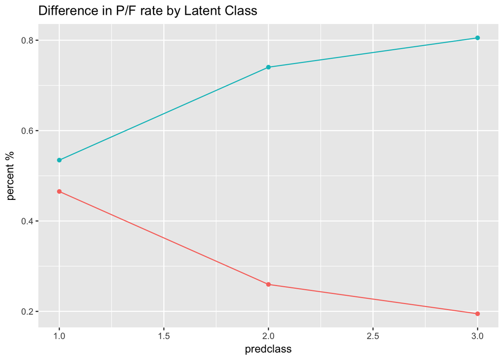

```r
student.train.lca <- cbind(student.train, best.lca.train$results$posterior, best.lca.train$results$predclass)
colnames(student.train.lca) <- c(colnames(student.train.lca)[-ncol(student.train.lca)],"predclass")

student.train.lca.group <- gb.func(student.train.lca, "id_student", "predclass","final_result_encoding", sort.by.col = F)
custom.plots$gg.comp.line(student.train.lca.group, "percent_id_student",
                          "predclass","final_result_encoding",
                          "Difference in P/F rate by Latent Class")
```

Now holdout analysis for LCA

```r
# create lca function ready for test
n <- 3
lca.res.test <- lca.analysis(student.test, lca.f.test.trim, 3, 37, probs.start = best.lca.train$results$probs)
lca.res.test$results
```

```
## Conditional item response (column) probabilities,
##  by outcome variable, for each class (row)
##
## $imd_band
##            0-10%  10-20 20-30% 30-40% 40-50% 50-60% 60-70% 70-80% 80-90%
## class 1:  0.2203 0.1856 0.1561 0.1363 0.0908 0.0792 0.0669 0.0492 0.0157
## class 2:  0.0000 0.0436 0.0691 0.0935 0.1164 0.1290 0.1223 0.1295 0.1482
## class 3:  0.0154 0.0423 0.0770 0.1032 0.1081 0.0904 0.0847 0.1328 0.1609
##           90-100%
## class 1:   0.0000
## class 2:   0.1484
## class 3:   0.1853
##
## $highest_education
##           A Level or Equivalent HE Qualification Lower Than A Level
## class 1:                 0.4215           0.0823             0.4766
## class 2:                 0.5657           0.0387             0.3956
## class 3:                 0.0964           0.8453             0.0005
##           No Formal quals Post Graduate Qualification
## class 1:           0.0197                      0.0000
## class 2:           0.0000                      0.0000
## class 3:           0.0000                      0.0578
##
## $gender
##                F      M
## class 1:  0.5098 0.4902
## class 2:  0.4572 0.5428
## class 3:  0.3492 0.6508
##
## $age_band
##             0-35  35-55   55<=
## class 1:  0.7497 0.2503 0.0000
## class 2:  0.7229 0.2742 0.0029
## class 3:  0.4602 0.4988 0.0410
##
## $region
##           East Anglian Region East Midlands Region Ireland London Region
## class 1:               0.0463               0.0656  0.0355        0.1676
## class 2:               0.1702               0.0908  0.0359        0.0359
## class 3:               0.0798               0.0389  0.0143        0.0813
```

[output cut: 28 more lines]

```
##                       Coefficient  Std. error  t value  Pr(>|t|)
## (Intercept)              -2.10008     0.21102   -9.952         0
## final_result_encoding     1.21515     0.13664    8.893         0
## =========================================================
## number of observations: 6469
## number of estimated parameters: 88
## residual degrees of freedom: 3811
## maximum log-likelihood: -45993.43
##
## AIC(3): 92162.86
## BIC(3): 92759.04
## X^2(3): 3763.053 (Chi-square goodness of fit)
##
## ALERT: estimation algorithm automatically restarted with new initial values
##
```

```r
lca.res.test$odds.table
```

```
##                                     Class_2     Class_3
## logits                            0.7466855   1.2151532
## Odds Ratio Chg in Class if Pass   2.1099948   3.3708104
## Odds Pct Chg in Class if Pass   110.9994775 237.0810362
## Odds Ratio Chg in Class if Fail   0.4739348   0.2966646
## Odds Pct Chg in Class if Fail   -52.6065177 -70.3335432
## Probability                       0.6784561   0.7712095
```

```r
lca.res.test$entropy
```

```
## [1] 0.6048687
```

```r
student.test.lca <- cbind(student.test, lca.res.test$results$posterior, lca.res.test$results$predclass)
colnames(student.test.lca) <- c(colnames(student.test.lca)[-ncol(student.test.lca)], "predclass")

(student.test.lca.group <- gb.func(student.test.lca,"id_student", "predclass","final_result_encoding", sort.by.col = F))
```

```
##   predclass final_result_encoding count_id_student percent_id_student
## 1         1                     0             1180          0.4368752
## 2         1                     1             1521          0.5631248
## 3         2                     0              713          0.2506151
## 4         2                     1             2132          0.7493849
## 5         3                     0              146          0.1738095
## 6         3                     1              694          0.8261905
```

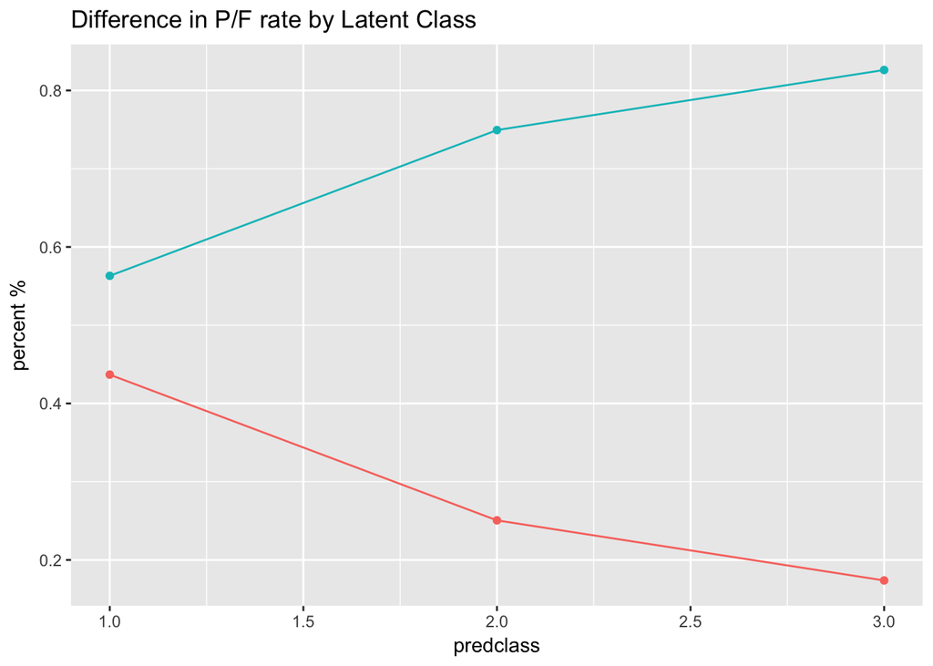

```r
custom.plots$gg.comp.line(student.test.lca.group, "percent_id_student",
                          "predclass","final_result_encoding",
                          "Difference in P/F rate by Latent Class")
```

Odds plot for LCA

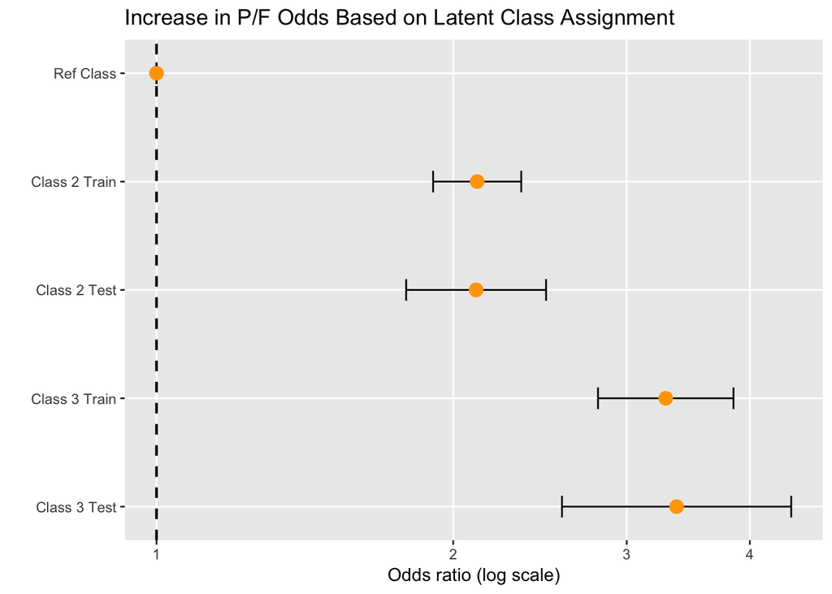

```r
# ODDS PLOT
# Create labels
labels <- c("Ref Class", "Class 2 Train", "Class 2 Test", "Class 3 Train", "Class 3 Test")

# coefficients come directly from the odds tables for train and test
qnorm.conf <- qnorm(c(0.025,0.5,0.975))

ci.class1.base <- exp(0 + qnorm.conf * 0.00)
ci.class2.train <- exp(0.74922 + qnorm.conf * 0.05252)
ci.class3.train <- exp(1.18977 + qnorm.conf * 0.08074)
ci.class2.test <- exp(0.74669 + qnorm.conf * 0.08340)
ci.class3.test <- exp(1.21515 + qnorm.conf * 0.13664)
collect.all.lca.odds <- rbind(ci.class1.base,ci.class2.train,ci.class2.test,ci.class3.train,ci.class3.test)

df.odds.plot <- data.frame(
  yAxis = length(labels):1,
  boxOdds = collect.all.lca.odds[,2],
  boxCILow = collect.all.lca.odds[,1],
  boxCIHigh = collect.all.lca.odds[,3]
)

odds.p <- ggplot(df.odds.plot, aes(x = boxOdds, y = yAxis))
odds.p + geom_vline(aes(xintercept = 1), size = .75, linetype = "dashed", color = "black") +
  geom_errorbarh(aes(xmax = boxCIHigh, xmin = boxCILow), size = .5, height = .2, color = "black") +
  geom_point(size = 3.5, color = "orange") +
  theme(panel.grid.minor = element_blank()) +
  scale_y_continuous(breaks = df.odds.plot$yAxis, labels = labels) +
  scale_x_continuous(breaks = seq(0,7,1) ) +
  coord_trans(x = "log10") +
  ylab("") +
  xlab("Odds ratio (log scale)") +
  ggtitle("Increase in P/F Odds Based on Latent Class Assignment")
```

Logistic regression

```r
# return all clicks results with spread so assessment numbers equal columns
student.results <- student.click.prep(students.clicks)
student.results$assess12 <- student.results$`1_assessment_submitted`+student.results$`2_assessment_submitted`
# make the train and test sets
class.split.helper <- function(df,k) {with(df, df[predclass==k,])}
students.final.train.df <- final.student.prep(student.train.lca,student.results)
students.final.train.1 <- class.split.helper(students.final.train.df,1)
students.final.train.2 <- class.split.helper(students.final.train.df,2)
students.final.train.3 <- class.split.helper(students.final.train.df,3)

# test data
students.final.test.df <- final.student.prep(student.test.lca,student.results)

#write.csv(students.final.train.df, "student.clicks.train.csv")
#write.csv(students.final.test.df, "student.clicks.test.csv")

# HARD CODED RIGHT NOW TO SHOW 1-3 ASSIGNMENTS
after.score.123 <- function(df, pr.vals = seq(0.4, 0.8, 0.02)){
  after.score.1 <- glm(final_result_encoding~code_module+code_presentation+
                         num_of_prev_attempts+`1_clicks_bw_assessments`+
                         `1_score`*`1_weight`+as.factor(`1_assessment_submitted`),
                       data=df,family="binomial")

  after.score.2 <- glm(final_result_encoding~code_module+code_presentation+num_of_prev_attempts+
                      `1_clicks_bw_assessments`+`2_clicks_bw_assessments`+
                       `1_score`*`1_weight`+as.factor(`1_assessment_submitted`)+
                        `2_score`*`2_weight`+as.factor(`2_assessment_submitted`)+
                        assess12,
                     data=df,family="binomial")

  # NOT USING ASSIGNMENT 3 RIGHT NOW
  after.score.3 <- glm(final_result_encoding~code_module+code_presentation+num_of_prev_attempts+
                      `1_clicks_bw_assessments`+`2_clicks_bw_assessments`+`3_clicks_bw_assessments`+
                      `1_score`*`1_weight`+as.factor(`1_assessment_submitted`)+
                      `2_score`*`2_weight`+as.factor(`2_assessment_submitted`)+
                      `3_score`*`3_weight`+as.factor(`3_assessment_submitted`),
                    data=df,family="binomial")

  after.1.res <- compute.lgres(df,after.score.1,1,pr.vals)
  after.2.res <- compute.lgres(df,after.score.2,2,pr.vals)
  after.3.res <- compute.lgres(df,after.score.3,3,pr.vals)
  res <- list(log.1 = after.score.1,
              log.2 = after.score.2,
              log.3 = after.score.3,
              logres.1 = after.1.res,
              logres.2 = after.2.res,
              logres.3 = after.3.res,
              all = cbind(after.1.res,after.2.res,after.3.res))
  return(res)
}

# REGRESSIONS USED FOR THE ROC PLOTS
logres.all <- after.score.123(students.final.train.df)
logres.class.1 <- after.score.123(students.final.train.1)
logres.class.2 <- after.score.123(students.final.train.2)
logres.class.3 <- after.score.123(students.final.train.3)

all.log.res.class.only <- glm(final_result_encoding~code_module+code_presentation+`1`+`2`+`3`+
                         num_of_prev_attempts,
                       data=students.final.train.df,family="binomial")

all.log.res.class.only.test <- predict(all.log.res.class.only, newdata = students.final.test.df, type="response")


all.log.res.1 <- glm(final_result_encoding~code_module+code_presentation+`1`+`2`+`3`+
                         num_of_prev_attempts+`1_clicks_bw_assessments`+`1_assessment_submitted`,
                       data=students.final.train.df,family="binomial")

all.log.res.1.test <- predict(all.log.res.1, newdata = students.final.test.df, type="response")

all.log.res.12 <- glm(final_result_encoding~code_module+code_presentation+`1`+`2`+`3`+
                         num_of_prev_attempts+`1_clicks_bw_assessments`+`2_clicks_bw_assessments`+
                         `1_assessment_submitted`+`2_assessment_submitted`,
                       data=students.final.train.df,family="binomial")

all.log.res.12.test <- predict(all.log.res.12, newdata = students.final.test.df, type="response")

logistic.res(all.log.res.class.only,students.final.train.df,0.7)
```

```
## $model.coeff
##                        Estimate Std. Error  z value Pr(>|z|)
## (Intercept)              2.4084     0.1641  14.6787   0.0000
## code_moduleBBB          -0.5922     0.1473  -4.0193   0.0001
## code_moduleCCC          -0.9990     0.1542  -6.4795   0.0000
## code_moduleDDD          -0.9331     0.1486  -6.2782   0.0000
## code_moduleEEE          -0.6372     0.1547  -4.1180   0.0000
## code_moduleFFF          -0.7046     0.1476  -4.7752   0.0000
## code_moduleGGG          -0.6499     0.1533  -4.2387   0.0000
## code_presentation2013J   0.1060     0.0591   1.7940   0.0728
## code_presentation2014B   0.0164     0.0623   0.2638   0.7919
## code_presentation2014J   0.3416     0.0595   5.7422   0.0000
## `1`                     -1.8754     0.0787 -23.8405   0.0000
## `2`                     -0.4782     0.0759  -6.2966   0.0000
## num_of_prev_attempts    -0.5358     0.0391 -13.6978   0.0000
##
## $model.aic
## [1] 17584.94
##
## $tbl.orig
##                0         1
## Actual  4846.000 10247.000
## Percent    0.321     0.679
##
## $tbl.model
##                0        1
## Actual  6992.000 8101.000
## Percent    0.463    0.537
##
## $conf.matrix.val
##    fv
##        0    1
##   0 3149 1697
##   1 3843 6404
##
## $conf.matrix.perc
##    fv
##        0    1
##   0 0.65 0.35
##   1 0.38 0.62
```

```r
logistic.res(all.log.res.1,students.final.train.df,0.7)
```

```
## $model.coeff
##                           Estimate Std. Error  z value Pr(>|z|)
## (Intercept)                -1.2097     0.2077  -5.8243   0.0000
## code_moduleBBB             -0.1957     0.1585  -1.2349   0.2169
## code_moduleCCC             -0.8345     0.1655  -5.0416   0.0000
## code_moduleDDD             -0.8193     0.1592  -5.1454   0.0000
## code_moduleEEE             -0.7828     0.1674  -4.6759   0.0000
## code_moduleFFF             -1.0395     0.1588  -6.5475   0.0000
## code_moduleGGG              0.0598     0.1668   0.3583   0.7201
## code_presentation2013J      0.1967     0.0643   3.0572   0.0022
## code_presentation2014B      0.1345     0.0681   1.9737   0.0484
## code_presentation2014J      0.3667     0.0646   5.6807   0.0000
## `1`                        -1.8025     0.0851 -21.1829   0.0000
## `2`                        -0.4348     0.0820  -5.3037   0.0000
## num_of_prev_attempts       -0.4085     0.0413  -9.8888   0.0000
## `1_clicks_bw_assessments`   0.0020     0.0001  21.1354   0.0000
## `1_assessment_submitted`    2.9912     0.1158  25.8413   0.0000
##
## $model.aic
## [1] 15308.29
##
## $tbl.orig
##                0         1
## Actual  4846.000 10247.000
## Percent    0.321     0.679
##
## $tbl.model
##                0        1
## Actual  6316.000 8777.000
## Percent    0.418    0.582
##
## $conf.matrix.val
##    fv
##        0    1
##   0 3334 1512
##   1 2982 7265
##
## $conf.matrix.perc
##    fv
##        0    1
##   0 0.69 0.31
##   1 0.29 0.71
```

```r
logistic.res(all.log.res.12,students.final.train.df,0.7)
```

```
## $model.coeff
##                           Estimate Std. Error  z value Pr(>|z|)
## (Intercept)                -2.1742     0.2222  -9.7844   0.0000
## code_moduleBBB             -0.1614     0.1620  -0.9966   0.3189
## code_moduleCCC             -0.0299     0.1722  -0.1733   0.8624
## code_moduleDDD             -0.6712     0.1628  -4.1238   0.0000
## code_moduleEEE             -0.5246     0.1724  -3.0430   0.0023
## code_moduleFFF             -1.1281     0.1633  -6.9085   0.0000
## code_moduleGGG              0.1870     0.1712   1.0928   0.2745
## code_presentation2013J      0.1742     0.0679   2.5674   0.0102
## code_presentation2014B      0.1444     0.0719   2.0084   0.0446
## code_presentation2014J      0.3294     0.0677   4.8677   0.0000
## `1`                        -1.7663     0.0898 -19.6646   0.0000
## `2`                        -0.4638     0.0863  -5.3735   0.0000
## num_of_prev_attempts       -0.3748     0.0437  -8.5833   0.0000
## `1_clicks_bw_assessments`   0.0009     0.0001   7.9416   0.0000
## `2_clicks_bw_assessments`   0.0020     0.0002  12.1703   0.0000
## `1_assessment_submitted`    1.6916     0.1313  12.8876   0.0000
## `2_assessment_submitted`    2.3063     0.0792  29.1062   0.0000
##
## $model.aic
## [1] 13952.22
##
## $tbl.orig
##                0         1
## Actual  4846.000 10247.000
## Percent    0.321     0.679
##
## $tbl.model
##                0        1
## Actual  5758.000 9335.000
## Percent    0.382    0.618
##
## $conf.matrix.val
##    fv
##        0    1
##   0 3361 1485
##   1 2397 7850
##
## $conf.matrix.perc
##    fv
##        0    1
##   0 0.69 0.31
##   1 0.23 0.77
```

```r
#(class.as.predictor <- compute.lgres(students.final.train.df,all.log.res,"all",seq(0.5, 0.8, 0.02)))
#round(summary(all.log.res)$coefficients,4)
```

```r
# ----------- NOTICE - MAJOR ISSUE WITH MULTICOLLINEARITY IN MULTIPLE ASSIGNMENTS ---------- #
# ----------- STUDENTS WHO SUBMITTED FIRST TWO ASSIGNMENTS WAY MORE LIKELY TO DO IT AGAIN ---------- #

#round(summary(logres.all$log.1)$coefficients,4)
#round(summary(logres.all$log.2)$coefficients,4)
#round(summary(logres.all$log.3)$coefficients,4)

# ----------- THEREFORE - LET'S GO WITH JUST THE FIRST ASSIGNMENT FOR NOW ---------- #
# ----------- COLLECT THE DIFFERENCES BETWEEN OVERALL INTERPRETABILITY SEPARATING CLASSES ---------- #

grand.rate <- (table(students.final.train.df$final_result_encoding) / sum(table(students.final.train.df$final_result_encoding)))[2]
rate.1 <- (table(students.final.train.1$final_result_encoding) / sum(table(students.final.train.1$final_result_encoding)))[2]
rate.2 <- (table(students.final.train.2$final_result_encoding) / sum(table(students.final.train.2$final_result_encoding)))[2]
rate.3 <- (table(students.final.train.3$final_result_encoding) / sum(table(students.final.train.3$final_result_encoding)))[2]

# Data Exploration TEsts
reppp <- function(p.val){
  all <- all.res$conf.matrix.val
  fp.all <- cbind(all,apply(all,1,sum))
  res.all <- c(fp.all[1,2]/fp.all[1,3],fp.all[2,1]/fp.all[2,3],sum(diag(fp.all[,-3]))/sum(fp.all[,-3]))
  summed <- on.1.res$conf.matrix.val+on.2.res$conf.matrix.val+on.3.res$conf.matrix.val
  fp.summed <- cbind(summed,apply(summed,1,sum))
  res.summed <- c(fp.summed[1,2]/fp.summed[1,3],fp.summed[2,1]/fp.summed[2,3],sum(diag(fp.summed[,-3]))/sum(fp.summed[,-3]))
  p.c <- rep(p.val,3)
  p.res <- c("fp","fn","acc")
  f <- cbind(p.c,p.res,round(res.all,3),round(res.summed,3))
  colnames(f) <- c("cb","stat","all","specific")
  return(as.data.frame(f))
}

# class splitting for test data
test.data.1 <- class.split.helper(students.final.test.df,1)
test.data.2 <- class.split.helper(students.final.test.df,2)
test.data.3 <- class.split.helper(students.final.test.df,3)

test.1 <- ifelse(predict(logres.class.1$log.1, newdata = test.data.1, type="response")>0.7,1,0)
test.2 <- ifelse(predict(logres.class.2$log.1, newdata = test.data.2, type="response")>0.7,1,0)
test.3 <- ifelse(predict(logres.class.3$log.1, newdata = test.data.3, type="response")>0.7,1,0)

fin.f <- c(logres.class.1$log.1$fitted.values,logres.class.2$log.1$fitted.values,logres.class.3$log.1$fitted.values)
fin.f10 <- ifelse(c(logres.class.1$log.1$fitted.values,logres.class.2$log.1$fitted.values,logres.class.3$log.1$fitted.values)>0.7,1,0)
fin.c <- c(students.final.train.1$final_result_encoding,students.final.train.2$final_result_encoding,
           students.final.train.3$final_result_encoding)
fin.f.test <- c(test.1,test.2,test.3)
fin.c.test <- c(test.data.1$final_result_encoding,
                test.data.2$final_result_encoding,
                test.data.3$final_result_encoding)
(train.conf <- round(prop.table(table(fin.c,fin.f10),1),2))
```

```
##      fin.f10
## fin.c    0    1
##     0 0.71 0.29
##     1 0.27 0.73
```

```r
(test.conf <- round(prop.table(table(fin.c.test,fin.f.test),1),2))
```

```
##           fin.f.test
## fin.c.test    0    1
##          0 0.73 0.27
##          1 0.30 0.70
```

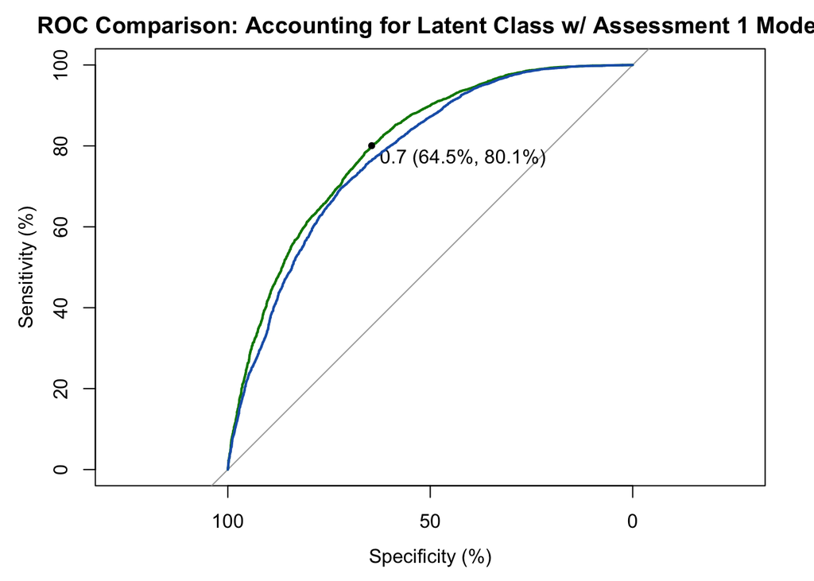

```r
#f.end <- r2c.func(plyr::ldply(lapply(seq(0.5,0.8,by=0.02),reppp),data.frame),stat,c(all,specific))
#f.end

# GENERATE THE ROC PLOTS

rocobj2.tr <- plot.roc(fin.c,
                        fin.f,
                        main="ROC Comparison: Accounting for Latent Class w/ Assessment 1 Model",
                        thresholds="best", # select the (best) threshold
                        print.thres="best",
                        percent=TRUE,
                        col="#008600")
rocobj1.tr <- lines.roc(students.final.train.df$final_result_encoding,
                    logres.all$log.1$fitted.values,
                    percent=TRUE,
                    col="#1c61b6")
```

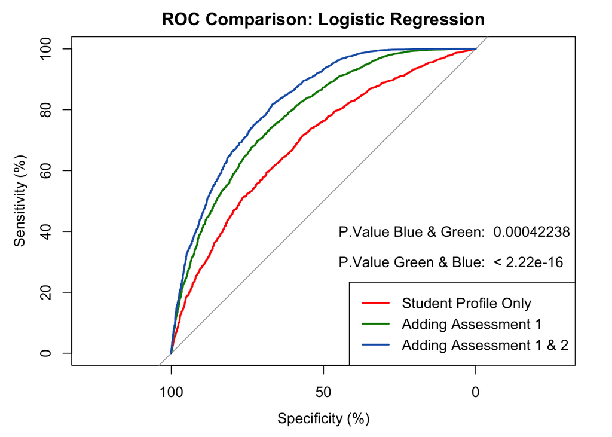

```r
# GENERATE THE ROC PLOTS FOR TEST ANALYSIS
rocobj1.tst <- plot.roc(students.final.test.df$final_result_encoding,
                    all.log.res.class.only.test,
                    main="ROC Comparison: Logistic Regression",
                    percent=TRUE,
                    col="red")
rocobj2.tst <- lines.roc(students.final.test.df$final_result_encoding,
                     all.log.res.1.test,
                     percent=TRUE,
                     col="#008600",
                     type="l")
rocobj3.tst <- lines.roc(students.final.test.df$final_result_encoding,
                     all.log.res.12.test,
                     percent=TRUE,
                     col="#1c61b6")
testobj <- roc.test(rocobj2.tr, rocobj1.tr)
testobj2 <- roc.test(rocobj2.tst, rocobj3.tst)
text(45, 40, labels=paste("P.Value Blue & Green: ", format.pval(testobj$p.value)), adj=c(0, .5))
text(45, 30, labels=paste("P.Value Green & Blue: ", format.pval(testobj2$p.value)), adj=c(0, .5))
legend("bottomright",
      legend=c("Student Profile Only", "Adding Assessment 1", "Adding Assessment 1 & 2"),
       col=c("red","#008600","#1c61b6"), lwd=2)
```

```r
fin.c <- ifelse(fin.c==1,TRUE,FALSE)
#fin <- ifelse(fin.f==1,TRUE,FALSE)
#logi.hist.plot(fin.f,fin.c,boxp=FALSE,type="hist",col="gray", main = "Logistic Regression Results From Class Separation")
```

```r
# LDA model using training dataset to predict final_result_encoding
lda.full <- qda(final_result_encoding~code_module+code_presentation+num_of_prev_attempts+
                    `1_clicks_bw_assessments`+
                    `1_score`+
                    `1_assessment_submitted`,
                  data=students.final.train.df)


# Prediction on training data
lda.full.predict <- predict(lda.full)$class

# Prediction on holdout data with full model trained above
lda.test <- predict(lda.full,newdata=students.final.test.df)$class

# Confusion matrix of training data compared to actual
(train_tbl_lda <- table(students.final.train.df$final_result_encoding,lda.full.predict))
```

```
##    lda.full.predict
##        0    1
##   0 1711 3135
##   1  656 9591
```

```r
(train_prop_lda <- round(prop.table(table(students.final.train.df$final_result_encoding,lda.full.predict),1),2))
```

```
##    lda.full.predict
##        0    1
##   0 0.35 0.65
##   1 0.06 0.94
```

```r
(sum(diag(train_tbl_lda))/sum(train_tbl_lda))
```

```
## [1] 0.748824
```

```r
# Confusion matrix of holdout data compared to actual
(test_tbl_lda <- table(students.final.test.df[,5],lda.test))
```

```
##    lda.test
##        0    1
##   F  415 2601
##   M  592 2861
```

```r
(test_prop_lda <- round(prop.table(table(students.final.test.df[,5],lda.test),1),2))
```

```
##    lda.test
##        0    1
##   F 0.14 0.86
##   M 0.17 0.83
```

```r
(sum(diag(test_tbl_lda))/sum(test_tbl_lda))
```

```
## [1] 0.5064152
```

```r
# QDA model using training dataset to predict final_result_encoding
qda.full <- qda(final_result_encoding~code_module+code_presentation+num_of_prev_attempts+
                    `1_clicks_bw_assessments`+
                    `1_score`+
                    `1_assessment_submitted`+
                    `1_assessment_submitted`,
                  data=students.final.train.df)

# Prediction on training data
qda.full.predict <- predict(qda.full)$class

# Prediction on holdout data with full model trained above
qda.test <- predict(qda.full,newdata=students.final.test.df)$class

# Confusion matrix of training data compared to actual
(train_tbl_qda <- table(students.final.train.df[,5],qda.full.predict))
```

```
##    qda.full.predict
##        0    1
##   F 1059 5919
##   M 1308 6807
```

```r
(train_prop_qda <- round(prop.table(table(students.final.train.df[,5],qda.full.predict),1),2))
```

```
##    qda.full.predict
##        0    1
##   F 0.15 0.85
##   M 0.16 0.84
```

```r
(sum(diag(train_tbl_qda))/sum(train_tbl_qda))
```

```
## [1] 0.5211688
```

```r
# Confusion matrix of holdout data compared to actual
(test_tbl_qda <- table(students.final.test.df[,5],qda.test))
```

```
##    qda.test
##        0    1
##   F  415 2601
##   M  592 2861
```

```r
(test_prop_qda <- round(prop.table(table(students.final.test.df[,5],qda.test),1),2))
```

```
##    qda.test
##        0    1
##   F 0.14 0.86
##   M 0.17 0.83
```

```r
(sum(diag(test_tbl_qda))/sum(test_tbl_qda))
```

```
## [1] 0.5064152
```

Finally, random forest with for assignment 1 as well.

```r
# Create the random forest for train

colnames(students.final.train.df)[c(22,23,28)] <- c("assessment_1_submitted","clicks_bw_assessments_1","score_1")
colnames(students.final.test.df)[c(22,23,28)] <- c("assessment_1_submitted","clicks_bw_assessments_1","score_1")
output.forest.train <- randomForest(final_result_encoding~code_module+code_presentation+num_of_prev_attempts+
                                      assessment_1_submitted+clicks_bw_assessments_1+score_1,data=students.final.train.df)
# train confusion matrix
zp=output.forest.train$predicted
zp[zp>=0.7]=1
zp[zp<0.7]=0
table(students.final.train.df$final_result_encoding,zp)
```

```
##    zp
##        0    1
##   0 3237 1609
##   1 2608 7639
```

```r
round(prop.table(table(students.final.train.df$final_result_encoding,zp),1),2)
```

```
##    zp
##        0    1
##   0 0.67 0.33
##   1 0.25 0.75
```

```r
# Create the random forest for test
rf.test <- predict(output.forest.train,newdata=students.final.test.df)

# test confusion matrix
xp=rf.test
xp[xp>=0.7]=1
xp[xp<0.7]=0
table(students.final.test.df$final_result_encoding,xp)
```

```
##    xp
##        0    1
##   0 1394  667
##   1 1128 3280
```

```r
round(prop.table(table(students.final.test.df$final_result_encoding,xp),1),2)
```

```
##    xp
##        0    1
##   0 0.68 0.32
##   1 0.26 0.74
```